# EB3I n1 2025 scRNAseq - **PRE-PROCESSING (II)** - Quality control : Counts & metrics

# 1 PREAMBLE

## 1.1 Purpose of this session

This file describes the different steps to perform the quality control of a single cell dataset, based on (per cell) :

- the number of **UMI** (~transcripts) detected
- the number of **expressed genes** detected
- the proportion of UMI corresponding to **mitochondrial** genes
- the proportion of UMI corresponding to **riboprotein-coding** genes
- the proportion of transcripts related to stress signature

**Input data**: A filtered, flat count matrix retrieved from GEO.

**Output data**: A `Seurat` object annotated for the “bad” cells to filter out for downstream analysis.

# 2 Start Rstudio

- Using the [OpenOnDemand/Rstudio cheat sheet](https://moodle.france-bioinformatique.fr/pluginfile.php/1475/mod_folder/content/0/OoD_R_Rstudio.html), connect to the [OpenOnDemand portal](https://ondemand.cluster.france-bioinformatique.fr) and **create a Rstudio session** with the right resource requirements, thanks to the cheat sheet.

# 3 Warm-up

- We now set **common parameters** as new variables, once and for all for this session :

```r
# setparam


## Set your project name
# WARNING : Do not just copy-paste this ! It's MY project name ! Put YOURS !!
project_name <- "ebaii_sc_teachers"


## Control if the project_name exists on the cluster
cat('PATH CHECK : ', dir.exists(paste0('/shared/projects/', project_name)))
```

**Show output**

```
PATH CHECK :  TRUE
```

```r
## Seed for the RNG
my_seed <- 1337L

# ## Empty droplets max p-value
# max_p <- 1E-03
```

# 4 Prepare the data structure

## 4.1 Main directory

```r
# maindir

## Preparing the path
TD_dir <- paste0("/shared/projects/", project_name, "/SC_TD")

## Creating the root directory
# dir.create(path = TD_dir, recursive = TRUE)

## Print the root directory on-screen
print(TD_dir)
```

**Show output**

```
[1] "/shared/projects/ebaii_sc_teachers/SC_TD"
```

## 4.2 Current session

```r
# sessiondir

## Creating the session (Preproc.2) directory
session_dir <- paste0(TD_dir, "/02_Preproc.2")
dir.create(path = session_dir, recursive = TRUE)

## Print the session directory on-screen
print(session_dir)
```

**Show output**

```
[1] "/shared/projects/ebaii_sc_teachers/SC_TD/02_Preproc.2"
```

## 4.3 Input directory

```r
# indir

## Creating the INPUT data directory
input_dir <- paste0(session_dir, "/DATA")
dir.create(path = input_dir, recursive = TRUE)

## Print the input directory on-screen
print(input_dir)
```

**Show output**

```
[1] "/shared/projects/ebaii_sc_teachers/SC_TD/02_Preproc.2/DATA"
```

## 4.4 Genelists directory

This is a directory where we will store additional information from knowledge bases about genes used to estimate the cell cycle phase of cells.

```r
# resdir

res_dir <- paste0(TD_dir, "/Resources")
glist_dir <- paste0(res_dir, "/Genelists")

## Create the directory
dir.create(path = glist_dir, recursive = TRUE)

## Print the resources directory on-screen
print(glist_dir)
```

**Show output**

```
[1] "/shared/projects/ebaii_sc_teachers/SC_TD/Resources/Genelists"
```

## 4.5 Output directory

```r
# outdir

## Creating the OUTPUT data directory
output_dir <- paste0(session_dir, "/RESULTS")
dir.create(path = output_dir, recursive = TRUE)

## Print the output directory on-screen
print(output_dir)
```

**Show output**

```
[1] "/shared/projects/ebaii_sc_teachers/SC_TD/02_Preproc.2/RESULTS"
```

# 5 Prerequisites

We have to retrieve the input data file

```r
# mat_dl

local <- FALSE

## The raw count matrix we will start from
scmat_source <- "GSM4861194_gex_2_raw_gene_expression.tsv.gz"

## Download the file from Zenodo
if (!local) {

  ### ZenID
  zen_id <- "14033941"
  ### Zen Path
  zen_backup_file <- paste0("https://zenodo.org/records/",
                            zen_id,
                            "/files/",
                            scmat_source)

  ## The path to the locally saved input file
  scmat_file <- paste0(input_dir,
                       '/',
                       scmat_source)
  ## Download the file
  download.file(url = zen_backup_file,
                destfile = scmat_file)
} else {
  ebaii_session <- '2538_eb3i_n1_2025'
  scmat_file <- paste0(
      '/shared/projects/',
      ebaii_session,
      '/atelier_scrnaseq/TD/BACKUP/TSV/',
      scmat_source)
}
```

# 6 Load the genelists resources

We retrieve the genelists

```r
# gl_dl

local <- FALSE

## The genelist files
mito_source <- "mus_musculus_mito_symbols_20191015.rds"
ribo_source <- "mus_musculus_cribo_symbols_20191015.rds"
stress_source <- "mus_musculus_stress_symbols_20200224.rds"
gl_sources <- c(mito_source, ribo_source, stress_source)

## The (future) local files
mito_file <- paste0(input_dir, '/', mito_source)
ribo_file <- paste0(input_dir, '/', ribo_source)
stress_file <- paste0(input_dir, '/', stress_source)
gl_files <- c(mito_file, ribo_file, stress_file)

## Download the file from Zenodo
if (!local) {

  ### ZenID
  zen_id <- "14037355"
  ### Looping on files
  for (glf in seq_along(gl_sources)) {
    ### Zen Path
    zen_backup_file <- paste0("https://zenodo.org/records/",
                              zen_id,
                              "/files/",
                              gl_sources[glf])

    ## Download the file
    download.file(url = zen_backup_file,
                  destfile = gl_files[glf])
  }
  rm(gl_files)
} else {  ## Local mode
  ebaii_session <- '2538_eb3i_n1_2025'
  localbackup_dir <- paste0('/shared/projects/', ebaii_session, '/atelier_scrnaseq/TD/RESOURCES/GENELISTS/')
  mito_file <- paste0(localbackup_dir, '/mus_musculus_mito_symbols_20191015.rds')
  ribo_source <- paste0(input_dir, '/mus_musculus_cribo_symbols_20191015.rds')
  stress_source <- paste0(input_dir, '/mus_musculus_stress_symbols_20200224.rds')
}
```

# 7 Biological context

For this series of training sessions, we will work on data from this [Paiva et al.](https://www.sciencedirect.com/science/article/pii/S2211124721002813) publication.

- The study concerns **thymus autonomy**:
  - The thymus is an “organ of passage”, critical in its function to the adaptive immune system for the maturation of T cell lymphocytes.
  - This maturation involves two main steps, performed thanks to macrophages:
    - Positive selection : keeping cells that successfully develop react appropriately with MHC immune receptors of the body
    - Negative selection : keeping cells that do not react against natural proteins of the body.
  - Thymus *autonomy* is a natural mechanism that allows to create T cells in the thymus by differentiation and cell competition, even when normal progenitors from the bone marrow are lacking, in critical conditions.
  - This mechanism is known in its effects, but the cells involved in are not.
  - This study is of importance in the health field, as this mechanism relies on a temporary loss of control of the cell normal functions.
  - The consequence is that if thymus is in autonomy for too long (few weeks), this is a prelude for leukemia !

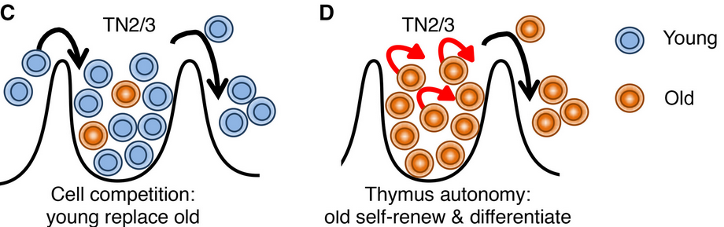

- Organism is : **mus musculus**
- Individuals are : newborn **mice, grafted**
- The design corresponds to **two conditions** (Test / Control)
  - **Control** : thymus from **wild type** newborn mice transplanted into **wild type** juvenile mouse. In this control case, **donor** T-cells progenitors (DN3) were replaced by **host** cells **3 weeks** after transplantation.
  - **Test** : thymus from **wild type** newborn mice transplanted in **KO Rag-/-** type juvenile mouse (the KO partially impairs their ability to produce T-cell progenitors in normal amounts). In this test case, **donor** T-cells progenitors (DN3) were replaced by **host** cells **9 weeks** after transplantation, showing that the donor DN3 cells outlived their normal lifespan by ~6 weeks.

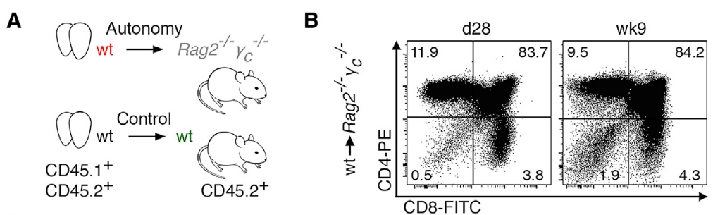

You will mainly work on the **KO sample : `TD3A`**.

The input data consists in a **count matrix**, as a gzipped tabular text file, that contains everything needed to create a basic Seurat object :

- The expressions **counts**
- The **feature names** (here, gene symbols)
- The **barcode names**

This matrix has already been **filtered for empty droplets**.

# 8 Environment

We load the packages of interest:

```r
# packages
library(ggplot2)
library(Seurat)
```

# 9 Data

We load the count matrix:

```r
# mat_load

## Loading the matrix directly as a sparseMatrix
scmat <- scuttle::readSparseCounts(
    file = scmat_file,
    sep = "\t")

## Displaying its size in-memory (this is a basic matrix)
format(utils::object.size(scmat), units = "auto")
```

**Show output**

```
[1] "88.3 Mb"
```

```r
# mat_desc

## A basic description of the matrix
dim(scmat)
```

**Show output**

```
[1] 31053  4587
```

```r
scmat[c(1:5), c(1:5)]
```

**Show output**

```
5 x 5 sparse Matrix of class "dgCMatrix"
        AAACCTGAGACGCTTT.1 AAACCTGAGGCATTGG.1 AAACCTGGTCAACATC.1
Xkr4                     .                  .                  .
Gm1992                   .                  .                  .
Gm37381                  .                  .                  .
Rp1                      .                  .                  .
Sox17                    .                  .                  .
        AAACCTGTCGAGGTAG.1 AAACCTGTCGATCCCT.1
Xkr4                     .                  .
Gm1992                   .                  .
Gm37381                  .                  .
Rp1                      .                  .
Sox17                    .                  .
```

We want to build a Seurat object from the count matrix.

But how do we do ??

```r
# mat2seurat

?Seurat::CreateSeuratObject()
```

```r
# make_sobj

sobj = Seurat::CreateSeuratObject(counts = scmat,
                                  assay = "RNA",
                                  project = "TD3A")
sobj
```

**Show output**

```
An object of class Seurat
31053 features across 4587 samples within 1 assay
Active assay: RNA (31053 features, 0 variable features)
 1 layer present: counts
```

We do not need the count matrix anymore :

```r
# rm_mat

rm(scmat)
```

We set the filtering thresholds based on quality control-related metrics.

Adjust them as necessary based on the figures.

```r
# set_thresholds

cut_nCount_RNA = 1000
cut_log10_nCount_RNA = log10(cut_nCount_RNA)
cut_nFeature_RNA = 750
cut_percent_mt = 5
cut_percent_rb = 20
cut_percent_st = 6
```

We define a nice palette to visualize the QC metrics:

```r
# color_palette

color_palette = c("lightgray", "#FDBB84", "#EF6548", "#7F0000", "black")
```

For the QC metrics related to the proportion of UMI belongs to a specific gene sets, we need to load the gene sets.

```r
# load_lists

## MITO
mito_symbols = readRDS(mito_file)
mito_symbols
```

**Show output**

```
 [1] "mt-Atp6" "mt-Atp8" "mt-Co1"  "mt-Co2"  "mt-Co3"  "mt-Cytb" "mt-Nd1"
 [8] "mt-Nd2"  "mt-Nd3"  "mt-Nd4"  "mt-Nd4l" "mt-Nd5"  "mt-Nd6"  "mt-Rnr1"
[15] "mt-Rnr2" "mt-Ta"   "mt-Tc"   "mt-Td"   "mt-Te"   "mt-Tf"   "mt-Tg"
[22] "mt-Th"   "mt-Ti"   "mt-Tk"   "mt-Tl1"  "mt-Tl2"  "mt-Tm"   "mt-Tn"
[29] "mt-Tp"   "mt-Tq"   "mt-Tr"   "mt-Ts1"  "mt-Ts2"  "mt-Tt"   "mt-Tv"
[36] "mt-Tw"   "mt-Ty"
```

```r
## RIBO
ribo_symbols = readRDS(ribo_file)
ribo_symbols
```

**Show output**

```
 [1] "Rpsa"   "Rps2"   "Rps3"   "Rps3a"  "Rps4x"  "Rps5"   "Rps6"   "Rps7"
 [9] "Rps8"   "Rps9"   "Rps10"  "Rps11"  "Rps12"  "Rps13"  "Rps14"  "Rps15"
[17] "Rps15a" "Rps16"  "Rps17"  "Rps18"  "Rps19"  "Rps20"  "Rps21"  "Rps23"
[25] "Rps24"  "Rps25"  "Rps26"  "Rps27"  "Rps27a" "Rps28"  "Rps29"  "Rps30"
[33] "Rpl3"   "Rpl4"   "Rpl5"   "Rpl6"   "Rpl7"   "Rpl7a"  "Rpl8"   "Rpl9"
[41] "Rpl10"  "Rpl10a" "Rpl11"  "Rpl12"  "Rpl13"  "Rpl13a" "Rpl14"  "Rpl15"
[49] "Rpl17"  "Rpl18"  "Rpl18a" "Rpl19"  "Rpl21"  "Rpl22"  "Rpl23"  "Rpl23a"
[57] "Rpl24"  "Rpl26"  "Rpl27"  "Rpl27a" "Rpl28"  "Rpl29"  "Rpl30"  "Rpl31"
[65] "Rpl32"  "Rpl34"  "Rpl35"  "Rpl35a" "Rpl36"  "Rpl44"  "Rpl37"  "Rpl37a"
[73] "Rpl38"  "Rpl39"  "Rpl40"  "Rpl41"  "Rplp0"  "Rplp1"  "Rplp2"
```

```r
## MECHANICAL STRESS
stress_symbols = readRDS(stress_file)
stress_symbols
```

**Show output**

```
 [1] "Atf3"     "Cmss1"    "Diaph1"   "Egr1"     "Fos"      "Gls"
 [7] "Gm48099"  "lsp90aa1" "lsp90ab1" "lfrd1"    "Jak1"     "Junb"
[13] "Kpna1"    "Nup210l"  "Peak1"    "Stat3"    "Actb"     "Camk1d"
[19] "Chka"     "Clic4"    "Fodl2"    "Hspa8"    "Jun"      "Jund"
[25] "Klf6"     "Litaf"    "Pecam1"   "Ptma"     "Sik3"     "Spag9"
[31] "Arih1"    "Azin1"    "Brd2"     "Chd4"     "Ctnnb1"   "Dennd4a"
[37] "Elf1"     "G3bp1"    "Ints6"    "Kdm6b"    "Lsmem1"   "Man1a"
[43] "Med13"    "Nfkbia"   "Nfkbiz"   "Nop58"    "Piezo1"   "Ppp1r15a"
[49] "Prkcg"    "Sqstm1"   "Taf4b"    "Tmsb4x"   "Ubc"      "Zfp36"
[55] "Abtb2"    "Adamts1"  "Adamts9"  "Ahnak"    "Ankrd28"  "Atp2a2"
[61] "Baz1a"    "Btg2"     "Ccdc138"  "Cd44"     "Cdkn1a"   "Elf2"
[67] "Ep400"    "Epas1"    "Erf"      "Ern1"     "Fabp4"    "Fosb"
[73] "Gm10073"  "Gsk3a"    "H3f3a"    "H3f3b"    "Hivep2"   "Klf4"
[79] "Lmna"     "lapkapk2" "Mapre1"   "Msn"      "Mylip"    "Nabp1"
[85] "Ncl"      "Nsd3"     "Nufip2"   "Plekhg2"  "Ppp1cb"   "Rnf19b"
[91] "Rps20"    "Rtn4"     "Runx1"    "Sertad2"  "Sptan1"   "Top1"
[97] "Vcl"      "Zbtb11"
```

We keep only the gene symbols available in our data :

```r
# subset_symbols

mito_symbols = intersect(mito_symbols, rownames(sobj))
mito_symbols
```

**Show output**

```
 [1] "mt-Atp6" "mt-Atp8" "mt-Co1"  "mt-Co2"  "mt-Co3"  "mt-Cytb" "mt-Nd1"
 [8] "mt-Nd2"  "mt-Nd3"  "mt-Nd4"  "mt-Nd4l" "mt-Nd5"  "mt-Nd6"
```

```r
ribo_symbols = intersect(ribo_symbols, rownames(sobj))
ribo_symbols
```

**Show output**

```
 [1] "Rpsa"   "Rps2"   "Rps3"   "Rps4x"  "Rps5"   "Rps6"   "Rps7"   "Rps8"
 [9] "Rps9"   "Rps10"  "Rps11"  "Rps12"  "Rps13"  "Rps14"  "Rps15"  "Rps15a"
[17] "Rps16"  "Rps17"  "Rps18"  "Rps19"  "Rps20"  "Rps21"  "Rps23"  "Rps24"
[25] "Rps25"  "Rps26"  "Rps27"  "Rps27a" "Rps28"  "Rps29"  "Rpl3"   "Rpl4"
[33] "Rpl5"   "Rpl6"   "Rpl7"   "Rpl7a"  "Rpl8"   "Rpl9"   "Rpl10"  "Rpl10a"
[41] "Rpl11"  "Rpl12"  "Rpl13"  "Rpl13a" "Rpl14"  "Rpl15"  "Rpl17"  "Rpl18"
[49] "Rpl18a" "Rpl19"  "Rpl21"  "Rpl22"  "Rpl23"  "Rpl23a" "Rpl24"  "Rpl26"
[57] "Rpl27"  "Rpl27a" "Rpl28"  "Rpl29"  "Rpl30"  "Rpl31"  "Rpl32"  "Rpl34"
[65] "Rpl35"  "Rpl35a" "Rpl36"  "Rpl37"  "Rpl37a" "Rpl38"  "Rpl39"  "Rpl41"
[73] "Rplp0"  "Rplp1"  "Rplp2"
```

```r
stress_symbols = intersect(stress_symbols, rownames(sobj))
stress_symbols
```

**Show output**

```
 [1] "Atf3"     "Cmss1"    "Diaph1"   "Egr1"     "Fos"      "Gls"
 [7] "Gm48099"  "Jak1"     "Junb"     "Kpna1"    "Nup210l"  "Peak1"
[13] "Stat3"    "Actb"     "Camk1d"   "Chka"     "Clic4"    "Hspa8"
[19] "Jun"      "Jund"     "Klf6"     "Litaf"    "Pecam1"   "Ptma"
[25] "Sik3"     "Spag9"    "Arih1"    "Azin1"    "Brd2"     "Chd4"
[31] "Ctnnb1"   "Dennd4a"  "Elf1"     "G3bp1"    "Ints6"    "Kdm6b"
[37] "Lsmem1"   "Man1a"    "Med13"    "Nfkbia"   "Nfkbiz"   "Nop58"
[43] "Piezo1"   "Ppp1r15a" "Prkcg"    "Sqstm1"   "Taf4b"    "Tmsb4x"
[49] "Ubc"      "Zfp36"    "Abtb2"    "Adamts1"  "Adamts9"  "Ahnak"
[55] "Ankrd28"  "Atp2a2"   "Baz1a"    "Btg2"     "Ccdc138"  "Cd44"
[61] "Cdkn1a"   "Elf2"     "Ep400"    "Epas1"    "Erf"      "Ern1"
[67] "Fabp4"    "Fosb"     "Gm10073"  "Gsk3a"    "H3f3a"    "H3f3b"
[73] "Hivep2"   "Klf4"     "Lmna"     "Mapre1"   "Msn"      "Mylip"
[79] "Nabp1"    "Ncl"      "Nsd3"     "Nufip2"   "Plekhg2"  "Ppp1cb"
[85] "Rnf19b"   "Rps20"    "Rtn4"     "Runx1"    "Sertad2"  "Sptan1"
[91] "Top1"     "Vcl"      "Zbtb11"
```

**Note**: A more robust analysis may use the gene *identifiers* (like EntrezID) rather than gene *symbols*.

# 10 Quality controls

## 10.1 Compute metrics

What is already available in the Seurat object ?

```r
# see_metadata

head(sobj@meta.data)
```

**Show output**

```
                   orig.ident nCount_RNA nFeature_RNA
AAACCTGAGACGCTTT.1       TD3A       2813         1594
AAACCTGAGGCATTGG.1       TD3A       2072         1365
AAACCTGGTCAACATC.1       TD3A       2025         1341
AAACCTGTCGAGGTAG.1       TD3A       1877         1241
AAACCTGTCGATCCCT.1       TD3A       2216         1441
AAACGGGCACTTACGA.1       TD3A       2445         1428
```

How do the two first QC metrics vary ?

```r
# summary_metadata

summary(sobj@meta.data)
```

**Show output**

```
 orig.ident    nCount_RNA     nFeature_RNA
 TD3A:4587   Min.   :  502   Min.   :  22
             1st Qu.: 1986   1st Qu.:1291
             Median : 2397   Median :1476
             Mean   : 3573   Mean   :1638
             3rd Qu.: 3134   3rd Qu.:1733
             Max.   :48875   Max.   :5975
```

In the column `nCount_RNA`, the maximum is far from the third quartile. For visualization purpose, we transform this column to log10 scale.

```r
# log10_ncount_RNA

sobj$log10_nCount_RNA = log10(sobj$nCount_RNA)

summary(sobj@meta.data)
```

**Show output**

```
 orig.ident    nCount_RNA     nFeature_RNA  log10_nCount_RNA
 TD3A:4587   Min.   :  502   Min.   :  22   Min.   :2.701
             1st Qu.: 1986   1st Qu.:1291   1st Qu.:3.298
             Median : 2397   Median :1476   Median :3.380
             Mean   : 3573   Mean   :1638   Mean   :3.429
             3rd Qu.: 3134   3rd Qu.:1733   3rd Qu.:3.496
             Max.   :48875   Max.   :5975   Max.   :4.689
```

We compute the percentage of UMI related to each of the three list of genes.

First, we compute the proportion of transcripts related to mitochondrial genes, per cell.

```r
# percent_mt

sobj = Seurat::PercentageFeatureSet(
  object = sobj,
  assay = "RNA",
  features = mito_symbols,
  col.name = "percent_mt")

summary(sobj$percent_mt)
```

**Show output**

```
   Min. 1st Qu.  Median    Mean 3rd Qu.    Max.
  0.000   1.985   2.489   2.997   3.125  97.250
```

Then, we compute the proportion of transcripts related to riboprotein-coding genes, per cell:

```r
# percent_rb

sobj = Seurat::PercentageFeatureSet(
  object = sobj,
  assay = "RNA",
  features = ribo_symbols,
  col.name = "percent_rb")

summary(sobj$percent_rb)
```

**Show output**

```
   Min. 1st Qu.  Median    Mean 3rd Qu.    Max.
  0.000   7.884   9.577  10.880  12.167  42.010
```

Finally, we compute the proportion of transcripts related to mechanical stress signature, per cell :

```r
# percent_st

sobj = Seurat::PercentageFeatureSet(
  sobj,
  assay = "RNA",
  features = stress_symbols,
  col.name = "percent_st")

summary(sobj$percent_st)
```

**Show output**

```
   Min. 1st Qu.  Median    Mean 3rd Qu.    Max.
  0.000   2.946   3.338   3.368   3.749  10.198
```

We now have all the QC-related metrics:

```r
# final_summary

summary(sobj@meta.data)
```

**Show output**

```
 orig.ident    nCount_RNA     nFeature_RNA  log10_nCount_RNA   percent_mt
 TD3A:4587   Min.   :  502   Min.   :  22   Min.   :2.701    Min.   : 0.000
             1st Qu.: 1986   1st Qu.:1291   1st Qu.:3.298    1st Qu.: 1.985
             Median : 2397   Median :1476   Median :3.380    Median : 2.489
             Mean   : 3573   Mean   :1638   Mean   :3.429    Mean   : 2.997
             3rd Qu.: 3134   3rd Qu.:1733   3rd Qu.:3.496    3rd Qu.: 3.125
             Max.   :48875   Max.   :5975   Max.   :4.689    Max.   :97.250
   percent_rb       percent_st
 Min.   : 0.000   Min.   : 0.000
 1st Qu.: 7.884   1st Qu.: 2.946
 Median : 9.577   Median : 3.338
 Mean   :10.880   Mean   : 3.368
 3rd Qu.:12.167   3rd Qu.: 3.749
 Max.   :42.010   Max.   :10.198
```

## 10.2 Failing cells

We identify the cells that do not pass the quality controls. This will be used for the visualization and later for cells filtering.

If the filtering thresholds are modified, do not forget to run again this chunk.

```r
# fail_cells
fail_percent_mt <- rownames(sobj@meta.data)[sobj$percent_mt > cut_percent_mt]

fail_percent_rb <- rownames(sobj@meta.data)[sobj$percent_rb > cut_percent_rb]

fail_percent_st <- rownames(sobj@meta.data)[sobj$percent_st > cut_percent_st]

fail_nFeature_RNA <- rownames(sobj@meta.data)[sobj$nFeature_RNA < cut_nFeature_RNA]

fail_nCount_RNA <- rownames(sobj@meta.data)[sobj$nCount_RNA < cut_nCount_RNA]
```

## 10.3 Visualization

This is difficult to handle the distribution of these metrics across cells. We opt for various visualization ways:

- **histogram**, showing the distribution of the metric
- **violin plot**, showing the distribution of the metric, useful if several datasets are considered
- **UMAP** (or alternatively, tSNE), showing the distribution of the metric over a 2D projection of cells

You may choose one of these visualization ways.

To generate the UMAP 2D projection, we need to run multiple `Seurat` commands in a row. Understanding these commands is not the purpose of the current course, but will be detailed in the next few ones. So just run :

```r
# quick_processing

sobj_tmp = Seurat::NormalizeData(sobj, verbose = FALSE)
sobj_tmp = Seurat::ScaleData(sobj_tmp, verbose = FALSE)
sobj_tmp = Seurat::FindVariableFeatures(sobj_tmp, verbose = FALSE)
sobj_tmp = Seurat::RunPCA(sobj_tmp, npcs = 21, verbose = FALSE)
sobj_tmp = Seurat::RunUMAP(sobj_tmp, dims = c(1:20), verbose = FALSE)
```

We can now visualize the cells on a 2D projection:

```r
# visualize_cells

Seurat::DimPlot(object = sobj_tmp,
                reduction = "umap") + Seurat::DarkTheme()
```

**Show plot**

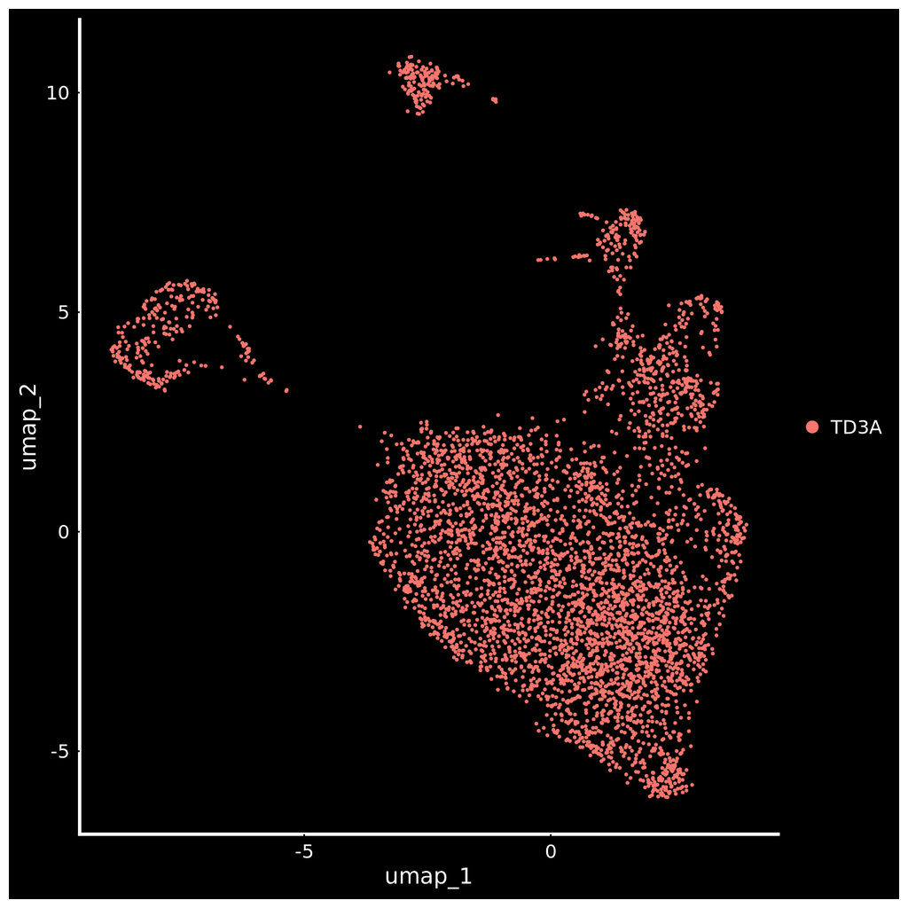

### 10.3.1 Define a R function

We want to visualize our different metrics, but using the same kind of plots. Instead of copying-pasting and editing the same code multiple times (this is time-consuming and error-prone), we design a **function** using the template below:

```r
# my_function_name

my_function_name = function(param1, param2) {
  # do something with the parameter values
  output = "something"

  return(output)
}
```

Here is the function we will use :

```r
# qc_print_function

print_1_qc_metric = function(object = sobj,
                             qc = "log10_nCount_RNA",
                             cut_qc = cut_log10_nCount_RNA,
                             failing_cells = fail_nCount_RNA) {
  # Description of the parameters:
  # - sobj : the Seurat object, with default value to the one
  # - qc : CHARACTER : the QC metric, must be a column in sobj@meta.data
  # - cut_qc : NUMERIC : the filtering threshold for the QC metric
  # - failing_cells : CHARACTER VECTOR : the cells that fail the QC

  # Histogram
  p_hist = ggplot(object@meta.data, aes(x = .data[[qc]])) +
    geom_histogram(aes(y = after_stat(density)),
                            colour = "black", fill = "#F8766D", bins = 100) +
    geom_density(alpha = 0, col = "blue", lwd = 0.75) +
    geom_vline(xintercept = cut_qc, col = "red") +
    labs(title = paste0("Threshold for ", qc, " is: ", cut_qc)) +
    theme_classic() +
    theme(plot.title = element_text(hjust = 0.5))

  # Violin plot
  p_violin = Seurat::VlnPlot(object, features = qc) +
    geom_hline(yintercept = cut_qc, col = "red") +
    theme(axis.title.x = element_blank(),
                   legend.position = "none")

  # Feature plot
  p_umap = Seurat::FeaturePlot(object,
                               reduction = "umap",
                               features = qc) +
    scale_color_gradientn(colors = color_palette) +
    theme(aspect.ratio = 1)

  # Dim plot
  object$failorpass = as.factor(
    ifelse(test = colnames(object) %in% failing_cells,
           yes = "fail",
           no = "pass")
    )

  p_fail = Seurat::DimPlot(object,
                           group.by = "failorpass",
                           order = "fail") +
    scale_color_manual(values = c("#F8766D", "gray80"),
                                breaks = levels(object$failorpass)) +
    labs(title = qc,
                  subtitle = paste0(length(failing_cells), " cells fail (",
                                    round(100*length(failing_cells)/ncol(sobj), 2), " %)")) +
    theme(aspect.ratio = 1,
                   plot.title = element_text(hjust = 0.5),
                   plot.subtitle = element_text(hjust = 0.5))


  ## If we applied the filter
  objectf = subset(object, cells = colnames(object)[object$failorpass == 'pass'])
  objectf = Seurat::ScaleData(objectf, verbose = FALSE)
  objectf = Seurat::FindVariableFeatures(objectf, verbose = FALSE)
  objectf = Seurat::RunPCA(objectf, npcs = 21, verbose = FALSE)
  objectf = Seurat::RunUMAP(objectf, dims = c(1:20), verbose = FALSE)

  p_umapf = Seurat::FeaturePlot(object = objectf,
                               reduction = "umap",
                               features = qc) +
    scale_color_gradientn(colors = color_palette) +
    theme(aspect.ratio = 1)

  # Patchwork
  p = patchwork::wrap_plots(p_umap, p_fail, p_hist, p_violin, p_umapf) +
    patchwork::plot_layout(nrow = 1, widths = c(1, 1, 2, 1, 1))

  return(p)
}
```

### 10.3.2 Number of UMI

#### 10.3.2.1 Check the function

This function should directly work for `log10_nCount_RNA`, as it is set for this metric by default (`qc = "log10_nCount_RNA"`) :

```r
# check1_log10_nCount_RNA

print_1_qc_metric(object = sobj_tmp)
```

**Show plot**

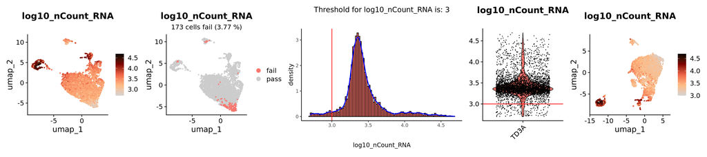

Of course, it will work the same by expliciting all of the parameters value:

```r
# check2_log10_nCount_RNA

print_1_qc_metric(object = sobj_tmp,
                  qc = "log10_nCount_RNA",
                  cut_qc = cut_log10_nCount_RNA,
                  failing_cells = fail_nCount_RNA)
```

**Show plot**

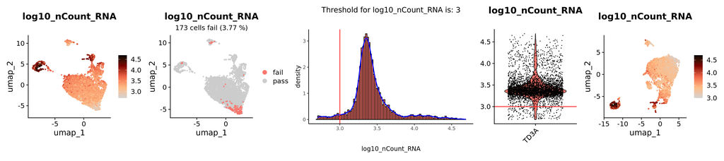

So we can copy-paste only this chunk for the next QC metrics !

### 10.3.3 Number of expressed genes

```r
# see_nFeature_RNA

print_1_qc_metric(object = sobj_tmp,
                  qc = "nFeature_RNA",
                  cut_qc = cut_nFeature_RNA,
                  failing_cells = fail_nFeature_RNA)
```

**Show plot**

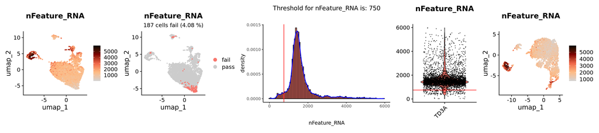

### 10.3.4 Mitochondrial genes expression

```r
# see_percent_mt

print_1_qc_metric(object = sobj_tmp,
                  qc = "percent_mt",
                  cut_qc = cut_percent_mt,
                  failing_cells = fail_percent_mt)
```

**Show plot**

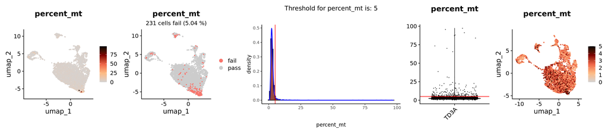

### 10.3.5 Riboprotein-coding genes expression

```r
# see_percent_rb

print_1_qc_metric(object = sobj_tmp,
                  qc = "percent_rb",
                  cut_qc = cut_percent_rb,
                  failing_cells = fail_percent_rb)
```

**Show plot**

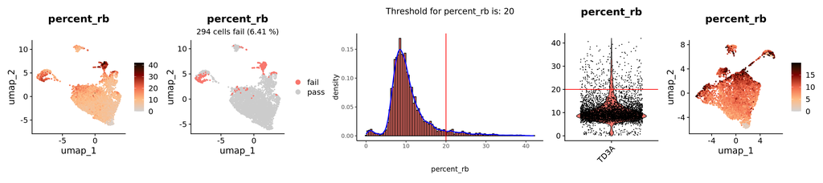

### 10.3.6 Mechanical stress genes expression

```r
# see_percent_st

print_1_qc_metric(object = sobj_tmp,
                  qc = "percent_st",
                  cut_qc = cut_percent_st,
                  failing_cells = fail_percent_st)
```

**Show plot**

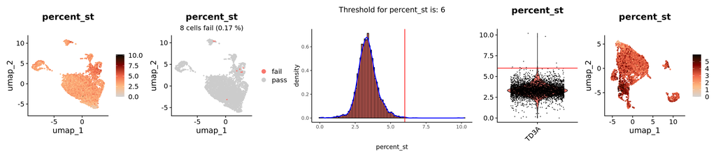

As we have finished with the visualization, we can discard our temporary object :

```r
# rm_sobj_tmp

rm(sobj_tmp)
```

### 10.3.7 All metrics effect

We can visualize metrics filtering effect as an **upset-plot**

```r
# bcupset

## Create a list of all cells filtered OUT for each criterion
up_list <-list(
  "nFeature" = fail_nFeature_RNA,
  "nCount" = fail_nCount_RNA,
  "%MITO" = fail_percent_mt,
  "%RIBO" = fail_percent_rb,
  "%STRESS" = fail_percent_st)

## Create an upset-plot
UpSetR::upset(data = UpSetR::fromList(up_list),
              nintersects = NA,
              sets = rev(names(up_list)),
              keep.order = TRUE,
              order.by = "freq")
```

**Show plot**

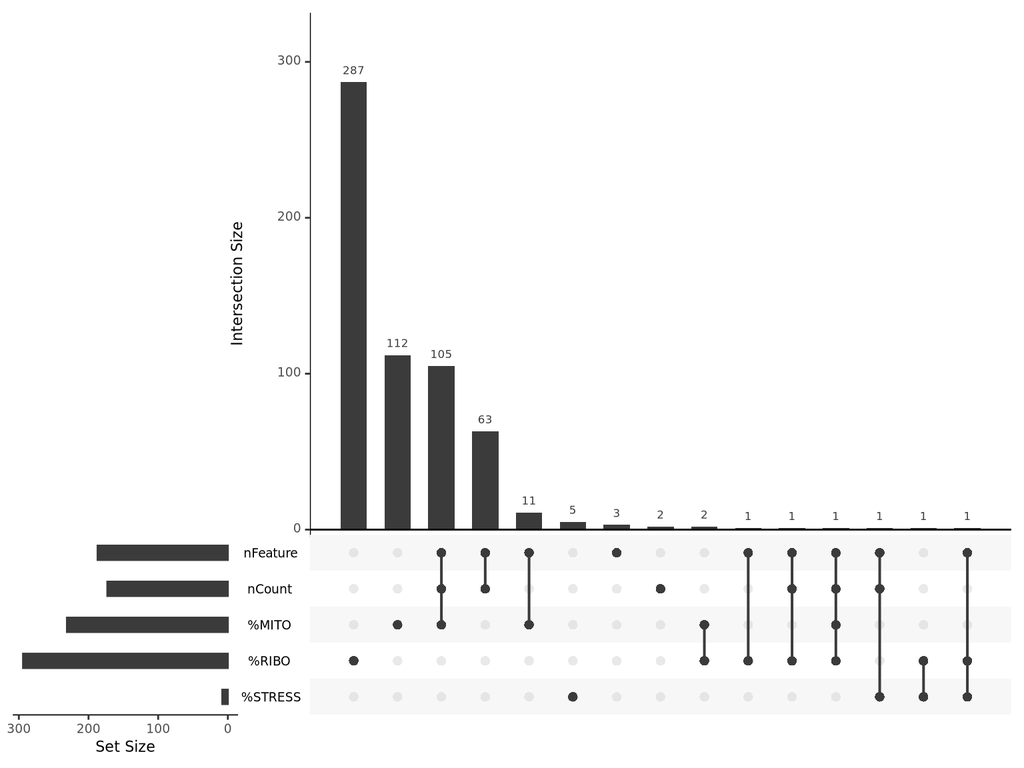

# 11 Filtering ?

We could filter out cells based on these 5 QC metrics now. It is also possible to wait, perform various annotations such as cell type annotation or cell cycle phase scoring, to better characterize the low quality cells.

To filter a Seurat object, we use the `Seurat::subset()` function:

```r
# filter_sobj

sobj_filtered = subset(sobj, invert = TRUE,
                       cells = unique(c(fail_nCount_RNA,
                                        fail_nFeature_RNA,
                                        fail_percent_mt,
                                        # fail_percent_rb, actually we decided not to filter on this parameter
                                        fail_percent_st
                                        )))

sobj_filtered
```

**Show output**

```
An object of class Seurat
31053 features across 4278 samples within 1 assay
Active assay: RNA (31053 features, 0 variable features)
 1 layer present: counts
```

We are **not going to save** this filtered Seurat object, but we want to store in our `sobj` Seurat object the cells that failed the QC as a new cell metadata :

```r
# add_fail_qc

sobj$fail_qc = ifelse(test = colnames(sobj) %in% colnames(sobj_filtered),
                      yes = "pass",
                      no = "fail")

table(sobj$fail_qc)
```

**Show output**

```
fail pass
 309 4278
```

# 12 Save

We save the **unfiltered** Seurat object:

```r
# saverds1

## Save our Seurat object (rich naming)
out_name <- paste0(
          output_dir, "/", paste(
            c("02", Seurat::Project(sobj), "S5",
              "Metrics", paste(
                dim(sobj),
                collapse = '.'
              )
            ), collapse = "_"),
            ".RDS")

## Check
print(out_name)
```

```
[1] "/shared/projects/ebaii_sc_teachers/SC_TD/02_Preproc.2/RESULTS/02_TD3A_S5_Metrics_31053.4587.RDS"
```

```r
## Write on disk
saveRDS(object = sobj,
        file = out_name)
```

This Seurat object would then be loaded as the input for further analyses.

# 13 R session

This is a good practice to show the version of the packages used in this notebook.

```r
# rsession

sessionInfo()
```

[output not shown]

**Show output**